# samplecase

2023-08-29

# 1.时间序列参数设置

```r
set.seed(1)
x <- periodic.series(start.period = 50,length = 1000)+rnorm(1000)
y <- periodic.series(start.period = 50,length = 1000)+rnorm(1000)
tsdf <- data.frame(x=x,y=y)
```

### 时间序列图

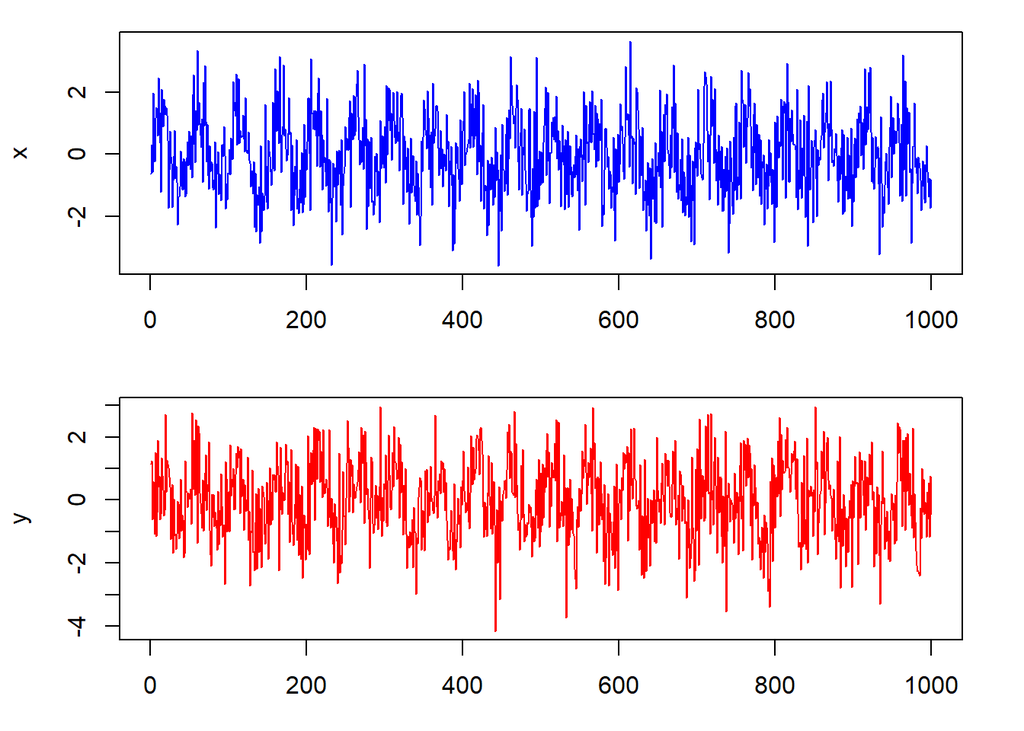

```r
par(mfrow = c(2,1),mar = c(3,4,1,2)+0.1)
plot(seq(1,dim(tsdf)[1]),tsdf$x,type ="l",col="blue",xlab="",ylab="x")
plot(seq(1,dim(tsdf)[1]),tsdf$y,type = "l",col="red",xlab="index",ylab="y")
```

### 相位差图

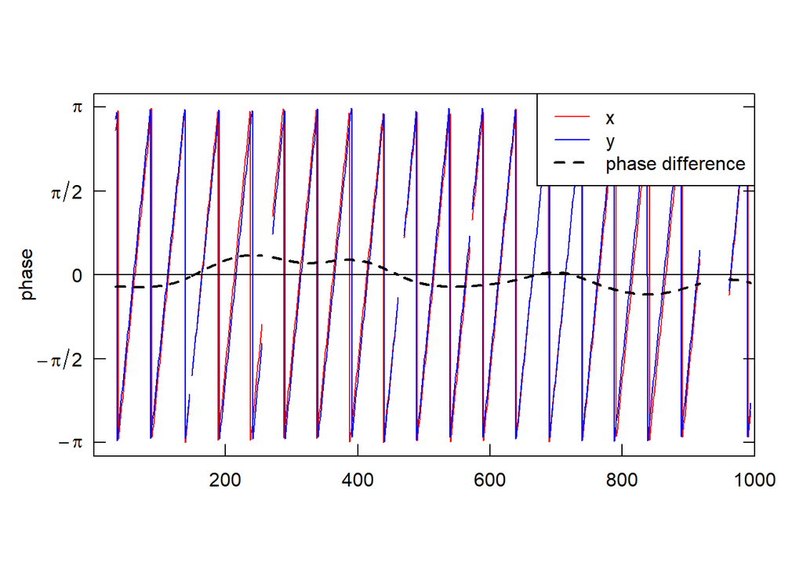

### 相位差序列直方图

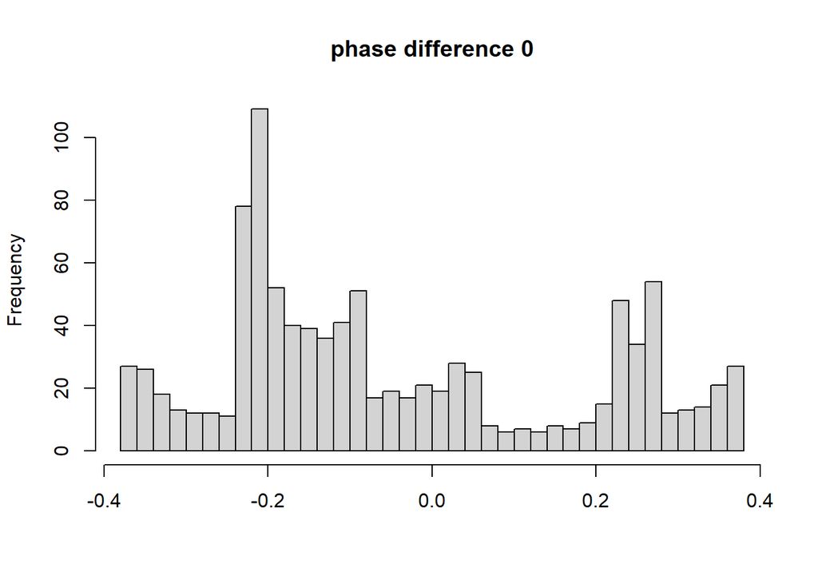

### 序列分块重抽样

```r
#重抽样函数
bphase <- function(times,x,y,phase.diff_fun){
  #传入参数:循环次数,需要计算小波相位角差值的两个时间序列
  cl <- makeCluster(detectCores())#设置并行环境
  registerDoParallel(cl)#设置为使用所有可用处理器核心
  #创建任务
  result <- foreach(i = 1:times,.combine='cbind') %dopar% {
    library(WaveletComp)
    sequence <- 1:length(x)
    # 将序列按照长度50为标准进行分块,分块数为20
    blocks <- matrix(sequence, nrow = 50)
    # 执行任务
    # 对分块进行随机重组产生新的排列顺序
    new_blocks <- c(blocks[, sample(ncol(blocks))])
    x_train <- x[new_blocks]
    tempwc <- analyze.coherency(data.frame(x=x_train,y=y),my.pair = c("x","y"),
                            loess.span = 0,
                            dt=1,dj=1/20,
                            lowerPeriod = 2,
                            upperPeriod = 128,
                            make.pval = T,
                            n.sim=10)
    #计算两时序在周期为50附近的小波相位角差值
    temphase <- phase.diff_fun(tempwc,50)
    invisible(temphase)
  }
  stopCluster(cl)#关闭进程
  return(result)
}
```

### 重抽相位差分布图

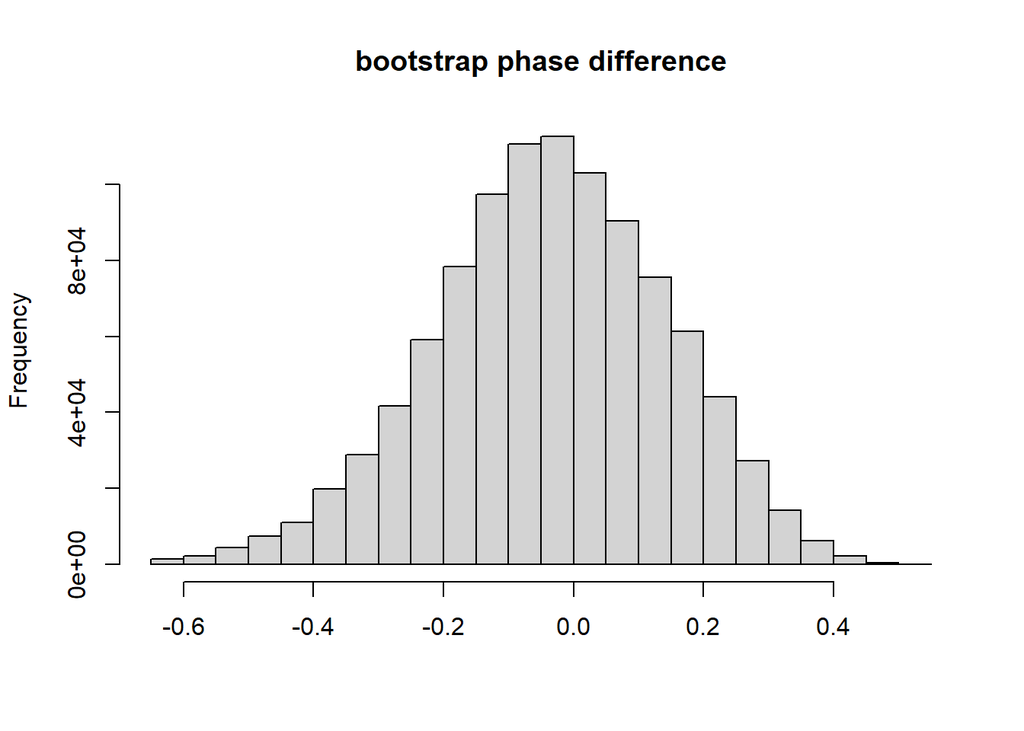

```r
#重抽样1000次
bootphase_1000 <- bphase(1000,x,y,phase.diff.extra)
hist(bootphase_1000,breaks=30,main = paste("bootstrap phase difference"),xlab='')#重抽样1000次相位差分布
```

### 重抽样相位差均值分布图

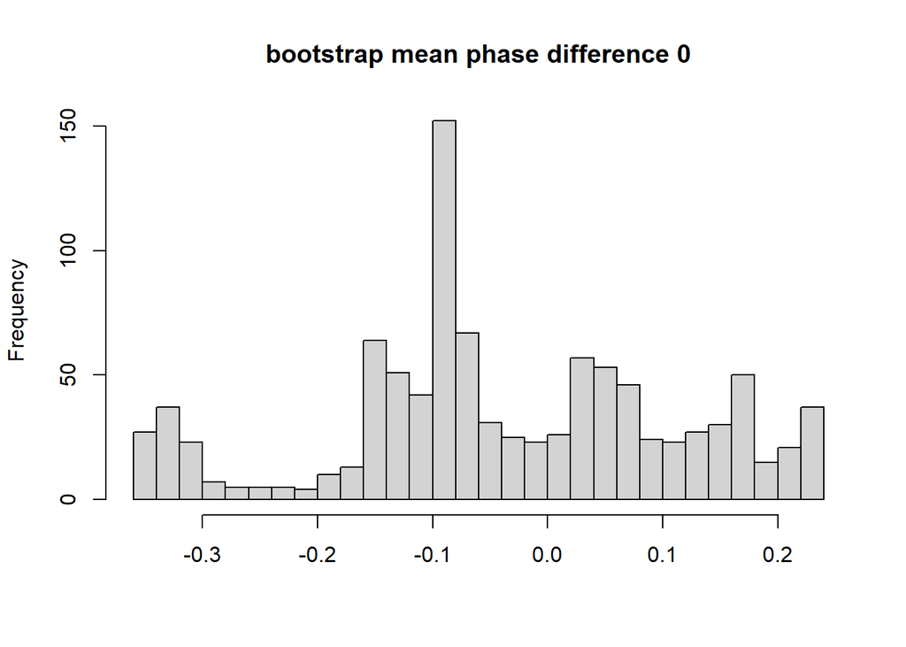

```r
#计算重抽样相位差均值
phase_matrix <- matrix(bootphase_1000, nrow = 1000)
# 计算每行的均值
row_means <- apply(phase_matrix, 1, mean)
hist(row_means,breaks=30,main = paste("bootstrap mean phase difference 0"),xlab='')#重抽样100次相位差分布
```

# 2.相位差检验

## 2.1时序构造

造两个时序
$$x=sin(2\pi f_x
t)+GWN(0,1)$$
$$y=sin(2\pi
f_xt-\frac{\pi}{5})+GWN(0,1)$$
两时间序列的相位差为$\frac{\pi}{5}\simeq 0.6283$

```r
cons_ts_pairs <- function(A,period,length,phasedif){
  #构造时间序列数据，参数：信噪比，周期，时序长度，相位差：X上的位移
  set.seed(1)
  x <- A*periodic.series(start.period = period,length = length)+rnorm(length)
  y <- A*periodic.series(start.period = period,phase=phasedif*period/(2*pi),length = length)+rnorm(length)
  tsdf <- data.frame(x=x,y=y)
  return(invisible(tsdf))
}
tsG1=cons_ts_pairs(1,50,1000,-pi/5)
```

### 时间序列图

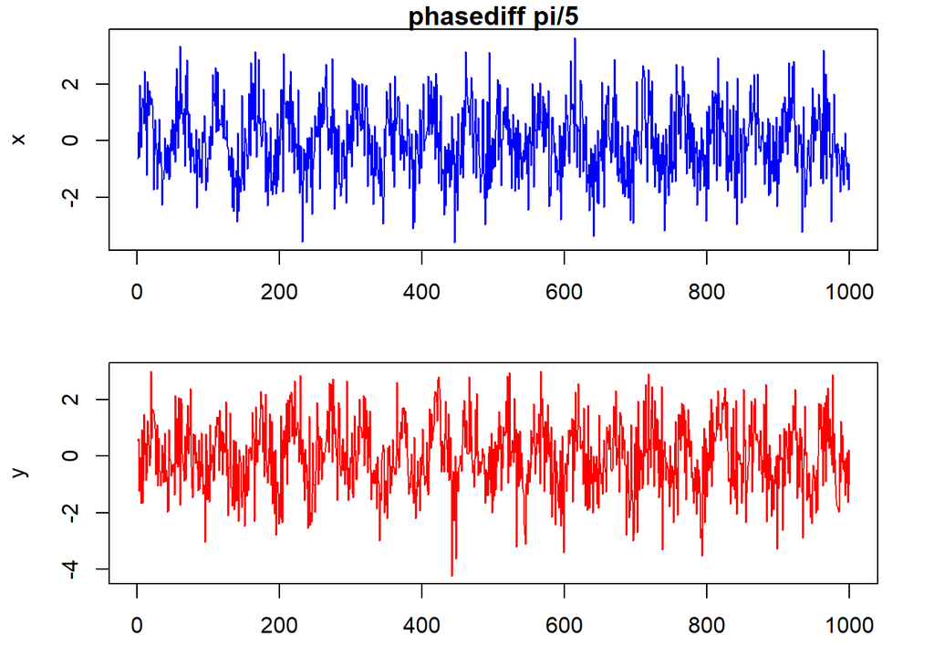

### 相位差为$\frac{pi}{5}$的相位差图

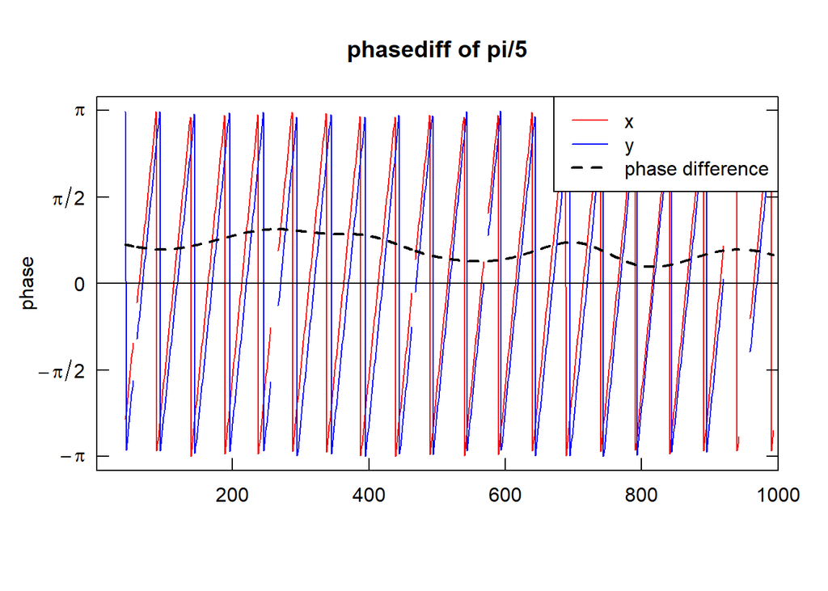

### 两序列相位差直方图

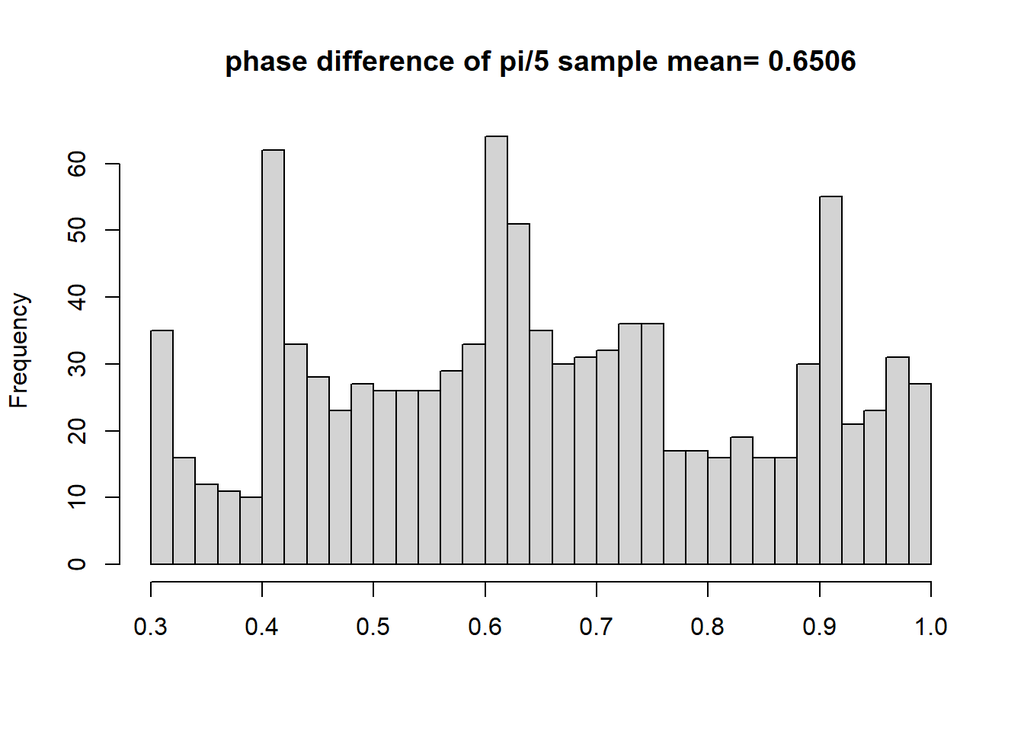

```r
phase_dis <- phase.diff.extra(tswcG1,50)
hist(phase_dis,breaks=30,main = paste("phase difference of pi/5",'sample mean=',round(mean(phase_dis),4)),xlab='')
```

## 2.2两序列重抽样1000次相位差直方图

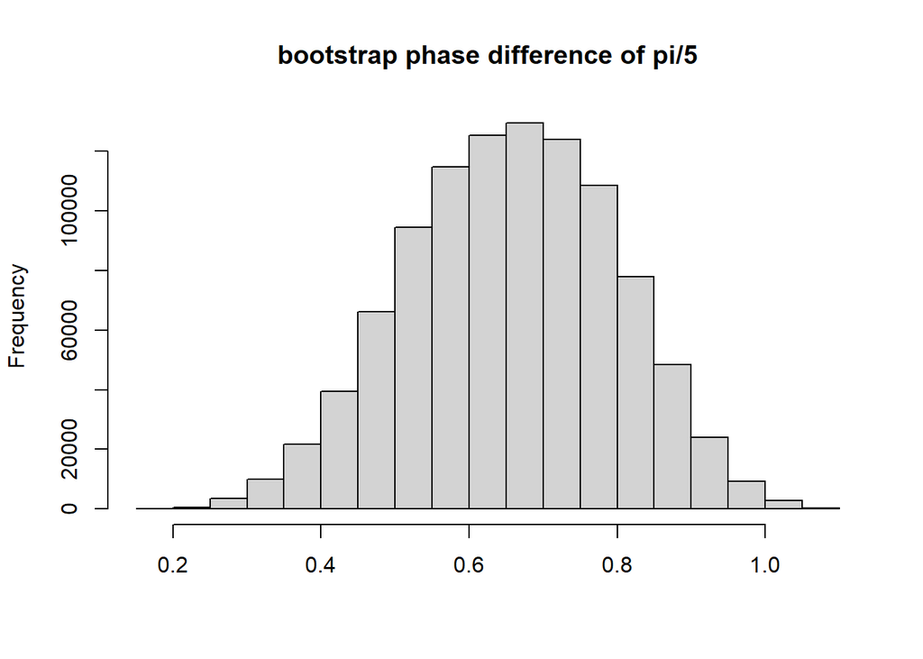

```r
#重抽样100次
bootphaseG1_1000 <- bphase(1000,tsG1$x,tsG1$y,phase.diff.extra)
hist(bootphaseG1_1000,breaks=30,main = paste("bootstrap phase difference of pi/5"),xlab='')#重抽样100次相位差分布
```

**对原始时间序列进行重抽样1000次，相位差近似正态分布,均值为0.6568**

### 两序列消除相位差

- 通过平移y序列相位差个单位，使得修正后的y_rec与x的相位差理论上为0，即符合原假设的情形
- 对x重抽样，计算每一次重抽样后与y_rec的相位差序列，画出重抽样相位差分布，构造出了符合原假设phasedif=0的相位差分布

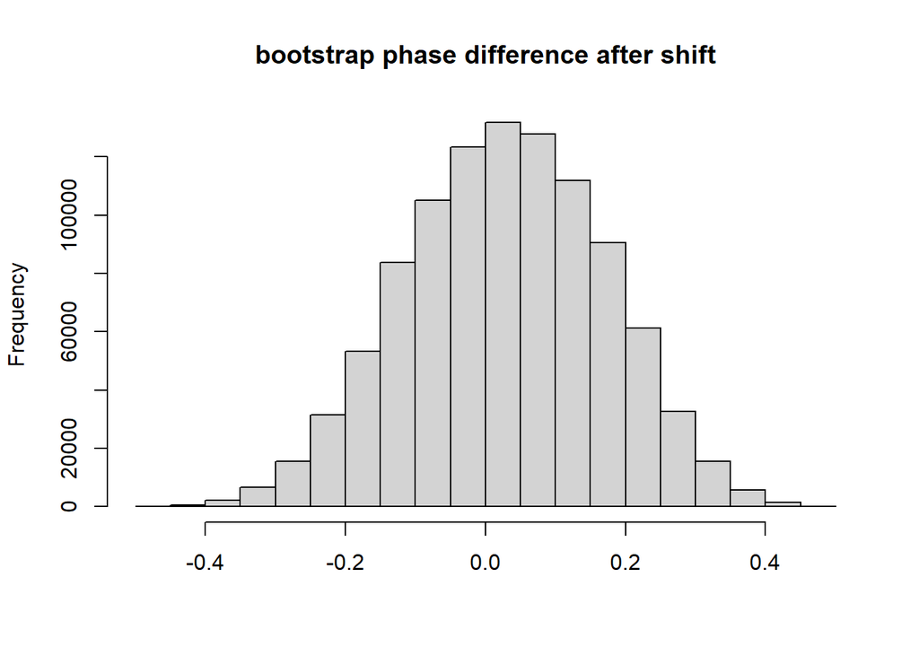

```r
#消除相位差
y_rec <- c(tsG1$y[6:1000],rep(0,5))
recphase <- bphase(1000,tsG1$x,y_rec,phase.diff.extra)
hist(recphase,breaks=30,main = paste("bootstrap phase difference after shift"),xlab='')#重抽样100次相位差分布
```

**平移后时间序列的相位差直方图仍近似呈正态分布，均值为0.0278**

### 重抽样相位差均值分布

我们感兴趣的统计量为相位差均值，对于构造出的符合原假设的重抽样相位差序列求均值，得到符合原假设的相位差均值分布

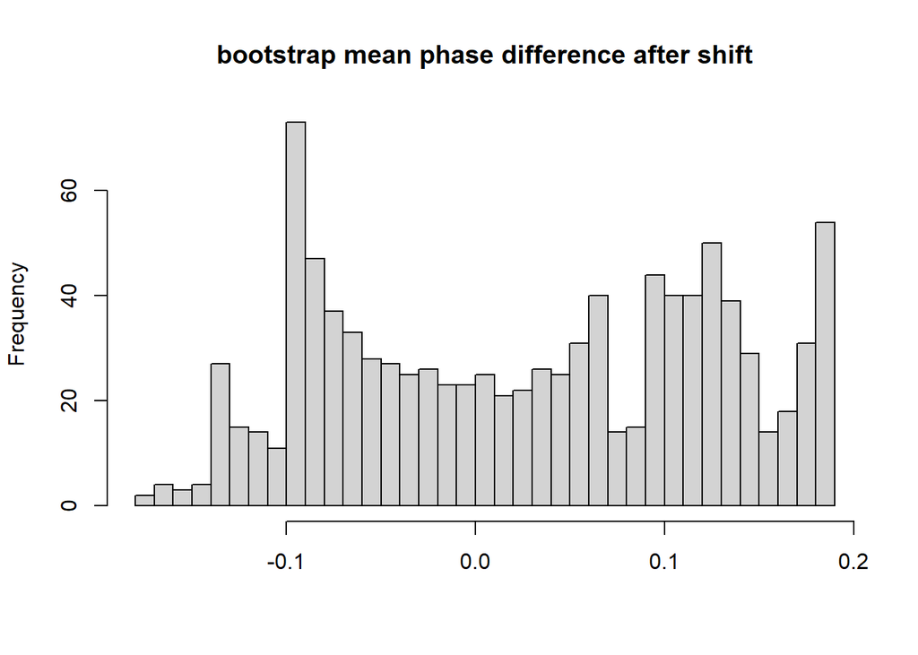

```r
#计算重抽样相位差均值
matrix_recphase <- matrix(recphase, nrow = 1000)
# 计算每行的均值
row_recmeans <- apply(matrix_recphase, 1, mean)
hist(row_recmeans,breaks=30,main = paste("bootstrap mean phase difference after shift"),xlab='')#重抽样100次相位差分布
```

### type_I_error

```r
alpha = 0.05  # 显著性水平
quantile(row_recmeans,probs=c(alpha/2,1-alpha/2))# 计算临界值
```

```
##       2.5%      97.5%
## -0.1356628  0.1853212
```

```r
sum(row_recmeans>mean(phase_dis))/length(row_recmeans)# type_I_error
```

```
## [1] 0
```

根据消除相位差后重抽样得到的相位差0的均值分布，在0.05显著性水平下，得到拒绝原假设的临界值，以及原始相位差为$\frac{pi}{5}$时在均值分布中的$p$值为0<0.05，即原始x,y时间序列的相位差显著不为0